# Cold Water Swimming

Chris Gaskell

29/07/2021

## About

This is an R markdown file to analyse the idiographic data collected from a SCED investigating the effectiveness of behavioural therapy (cold showers and cold water swimming) for major depressive disorder. The design for the study was an A-B-A-C-FU (or Baseline, Intervention 1, Withdrawal, Intervention 2, Follow-Up). The two intervention phases differed in that the former included cold shower, while the latter included both cold showers and cold water swimming.

The three idiographic variables (i.e. dependent variables) represented self-report measures on a scale of 1-100. These included happiness (or conversely sad); excitement (or boredom); and finally anxiousness (or calmness). Positive change was indicated by an increase in scores for the sad-to-happy and board-to-excited measures, and by a decrease in scores for the calm-to-anxious measure.

# Hypotheses/pair-wise comparisons

Because the current study involved five phases (i.e. A-B-A-C-FU) there was subsequently as large number of potential pairwise comparison combinations which could be made. We selected four pairwise comparisons to fit with the hypotheses of the current study: 1. That introducing a basic behavioural treatment (i.e. cold showers) would lead to an improvement in depression measures (by comparing baseline with the first behavioural treatment). 2. That the treatment effects from the initial behavioural treatment would be not be sustained when the treatment is removed (by comparing withdrawal phase with original baseline phase). 3. That an additive treatment component of cold water swimming would lead to enhanced outcomes when compared with cold showers only (by comparing both treatment phases). 4. The the effects of treatment would be maintained by introduction of a relapse prevention plan (by comparing treatment 2 with the follow-up phase).

# Descriptive Statistics

Across the fives phases of the three idiographic measures there were no missing values. The data-set was therefore complete with no imputation needed. The means, standard deviations (SD), and trends are reported in the table.

|  | SadHappy | AnxiousCalm | BoredExcited |
| --- | --- | --- | --- |
| **Baseline** |  |  |  |
| mean_a | 13.57 | 32.46 | 19.46 |
| sd_a | 2.73 | 2.47 | 2.12 |
| trend_a | -0.13 | 0.02 | -0.02 |
| **Cold Showers** |  |  |  |
| mean_b | 41.14 | 32.81 | 35.02 |
| sd_b | 5.25 | 2.13 | 6.51 |
| trend_b | 0.24 | -0.02 | 0.24 |
| **Withdrawal** |  |  |  |
| mean_a2 | 16.14 | 31.82 | 20.14 |
| sd_a2 | 3.78 | 2.18 | 2.81 |
| trend_a2 | -0.09 | -0.08 | 0.17 |
| **Cold Water** |  |  |  |
| mean_c | 60.64 | 32.10 | 57.40 |
| sd_c | 7.71 | 2.26 | 10.41 |
| trend_c | 0.41 | -0.08 | 0.72 |
| **Follow Up** |  |  |  |
| mean_fu | 68.84 | 30.66 | 73.16 |
| sd_fu | 9.55 | 2.27 | 8.21 |
| trend_fu | 0.15 | -0.02 | -0.04 |

# Kendall’s Tau

```
## $A1vsB
## Tau-U
## Method:  complete
##
## Overall Tau-U:
##                        Model Tau_U     se     z df        p
##                      A vs. B 0.981 0.0042 233.5  2 0.00e+00
##            A vs. B - Trend A 0.587 0.0437  13.4  2 3.52e-41
##            A vs. B + Trend B 0.579 0.0443  13.1  2 4.75e-39
##  A vs. B + Trend B - Trend A 0.555 0.0460  12.1  2 1.36e-33
##
## $SadHappy
##                             kendall      k_p  n pairs  pos neg ties    S    D
## A vs. B                       0.714 1.69e-12 70  1176 1176   0    0 1176 1176
## Trend A                      -0.309 2.71e-02 28   378  110 219   49 -109  353
## Trend B                       0.413 1.92e-04 42   861  572 229   60  343  830
## A vs. B - Trend A             0.679 1.57e-13 70  1554 1395 110   49 1285 1893
## A vs. B + Trend B             0.701 1.45e-15 70  2037 1748 229   60 1519 2167
## A vs. B + Trend B - Trend A   0.690 1.35e-16 70  2415 1967 339  109 1628 2360
##                                Tau  SD_S VAR_S SE_Tau     Z        p
## A vs. B                      1.000 166.8 27832 0.1419  7.05 1.80e-12
## Trend A                     -0.309  50.6  2562 0.1435 -2.15 3.13e-02
## Trend B                      0.413  92.3  8514 0.1111  3.72 2.01e-04
## A vs. B - Trend A            0.679 173.9 30258 0.0919  7.39 1.50e-13
## A vs. B + Trend B            0.701 190.2 36176 0.0878  7.99 1.39e-15
## A vs. B + Trend B - Trend A  0.690 196.8 38716 0.0834  8.27 1.30e-16
##
## $AnxiousCalm
##                             kendall   k_p  n pairs  pos  neg ties   S    D
## A vs. B                      0.0492 0.644 70  1176  545  468  163  77 1094
## Trend A                      0.0000 0.984 28   378  163  163   52   0  351
## Trend B                     -0.0212 0.843 42   861  364  381  116 -17  801
## A vs. B - Trend A            0.0428 0.659 70  1554  708  631  215  77 1800
## A vs. B + Trend B            0.0291 0.754 70  2037  909  849  279  60 2060
## A vs. B + Trend B - Trend A  0.0267 0.762 70  2415 1072 1012  331  60 2243
##                                 Tau  SD_S VAR_S SE_Tau      Z     p
## A vs. B                      0.0704 166.8 27832 0.1524  0.462 0.644
## Trend A                      0.0000  50.6  2562 0.1442  0.000 1.000
## Trend B                     -0.0212  92.3  8514 0.1152 -0.184 0.854
## A vs. B - Trend A            0.0428 172.0 29579 0.0956  0.448 0.654
```

[output cut: 183 more lines]

```
## $BoredExcited
##                             kendall      k_p  n pairs  pos  neg ties    S    D
## A vs. B                       0.629 6.08e-12 98  2352 1954  171  227 1783 2238
## Trend A                       0.751 2.48e-11 42   861  683   76  102  607  808
## Trend B                      -0.190 7.66e-02 56  1540  181  353 1006 -172  907
## A vs. B - Trend A             0.355 1.65e-05 98  3213 2030  854  329 1176 3314
## A vs. B + Trend B             0.442 2.94e-08 98  3892 2135  524 1233 1611 3647
## A vs. B + Trend B - Trend A   0.249 9.18e-04 98  4753 2211 1207 1335 1004 4031
##                                Tau  SD_S VAR_S SE_Tau     Z        p
## A vs. B                      0.797 278.6 77616 0.1245  6.40 1.55e-10
## Trend A                      0.751  92.3  8514 0.1141  6.58 4.76e-11
## Trend B                     -0.190 141.5 20020 0.1560 -1.22 2.24e-01
## A vs. B - Trend A            0.355 272.8 74402 0.0823  4.31 1.62e-05
## A vs. B + Trend B            0.442 290.4 84303 0.0796  5.55 2.88e-08
## A vs. B + Trend B - Trend A  0.249 302.6 91577 0.0751  3.32 9.08e-04
```

# Baseline analyses

The trends for the baseline period can be seen visually in the plots and statistically from the table. When using Kendall’s Tau to measure the trend of the baseline periods there was a significant trend for happiness (t = -0.31, p = 0.031) but not for anxiousness (t = 0, p = 1) or boredom (t = -0.12, p = 0.57). As the trend for happiness showed a worsening, and the remaining variables did not show a significant trend, there was no need to apply statistical adjustment (i.e. for baseline trend) within the following analyses.

The baseline and withdrawal phases are visually comparable. In terms of trends shown within the withdrawal period there was no significant trend shown for happiness (t = -0.22, p = 0.12) or anxiousness (t = -0.14, p = 0.33) however there was a significant trend for boredom (t = 0.36, p = 0.01). This indicates that during the withdrawal period there was some level of improvement across the phase.

In terms of level difference, Mann-whittney U tests were computed to determine is there was a statistically significant difference between the baseline and the withdrawal period. For happiness, there was a greater level of happiness shown in the withdrawal phase than the baseline phase. There was no significant difference for the Mann-whittney test for the boredom and anxiousness idiographics. Taken into account, there was small, limited evidence (statistically and visually) for differences between the baseline and withdrawal phases.

# Non-overlap Statistics

```
## $AvsB
##      case     PND     PEM     NAP NAP_SE
## 1 Anxious   0.00%  42.86%  53.27%   0.07
## 2 Excited  80.95%  98.81%  98.60%   0.01
## 3   Happy 100.00% 100.00% 100.00%   0.00
##
## $AvsA2
##      case   PND    PEM    NAP NAP_SE
## 1 Anxious 0.00% 28.57% 41.52%   0.08
## 2 Excited 3.57% 60.71% 63.58%   0.08
## 3   Happy 7.14% 83.93% 73.34%   0.07
##
## $BvsC
##      case    PND    PEM    NAP NAP_SE
## 1 Anxious  0.00% 33.33% 41.47%   0.06
## 2 Excited 78.57% 97.62% 97.14%   0.02
## 3   Happy 88.10% 95.24% 96.37%   0.02
##
## $CvsFU
##      case   PND    PEM    NAP NAP_SE
## 1 Anxious 1.79% 87.50% 75.57%   0.06
## 2 Excited 0.00%  8.93% 12.10%   0.04
## 3   Happy 1.79% 15.18% 20.79%   0.04
```

[figure not shown]

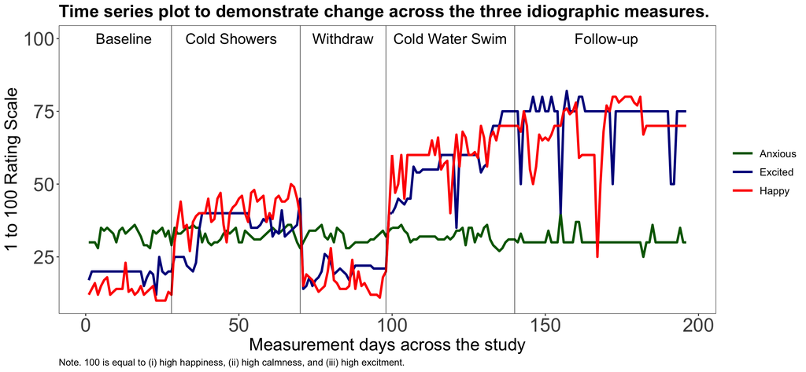

# Regression Analyses

Both the piecewise and the generalised regression are analyses to determine change between phases. Bi-phasic comaprisons are possible but it does not seemt that more than 2 can be used meaningfully in a single model. The following regression analyses explores change following the introduction of the first intervention (i.e. A vs. B).

# Piecewise Regression

|  | measure | D | Rsq.null | Rsq.mdl | ESr | Level.change | cohensD |
| --- | --- | --- | --- | --- | --- | --- | --- |
| 1 | Happy | 944.62 | 0.76 | 0.93 | 0.73 | 24.60 | -5.25 |
| 2 | Excited | 1490.58 | 0.67 | 0.75 | 0.25 | 10.81 | -2.39 |
| 3 | Anxious | 349.15 | 0.00 | 0.01 | 0.01 | 0.37 | -0.15 |

# Generalised Logistic Regression

|  | measure | D | Rsq.null | Rsq.mdl | ESr | growthRate | IP | base | top |
| --- | --- | --- | --- | --- | --- | --- | --- | --- | --- |
| 1 | Happy | 2602.39 | 0.82 | 2.78 | 0.99 | 0.11 | 33.97 | 10.27770 | 50 |
| 2 | Excited | 1726.39 | 0.71 | 3.24 | 0.91 | 0.07 | 37.71 | 15.00000 | 45 |
| 3 | Anxious | 352.72 | 0.00 | 2.98 | 0.84 | 0.00 | 27.00 | 29.25728 | 36 |

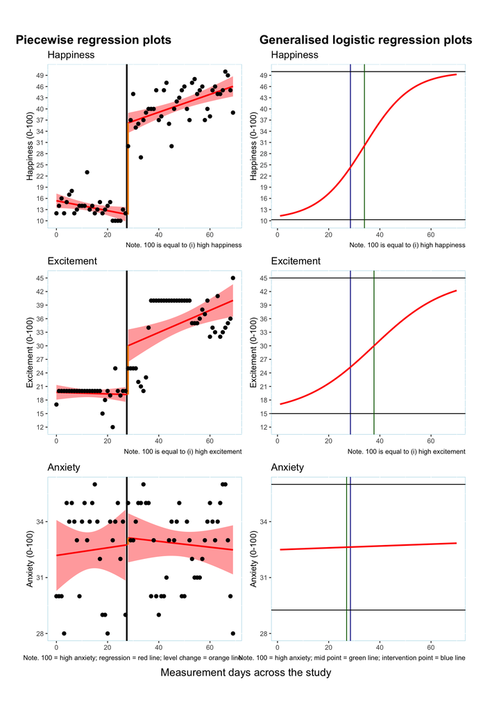